# Minería de Datos: Wine Quality Analytics

Pipeline Científico: Análisis Univariado vs Multivariado

Estudiante:** Percy Elbis Colque Caillahua **Curso:** Minería de Datos **Docente:** Dr. Cleto De La Torre Dueñas

03 de Octubre de 2026

# 1 Introducción y Carga de Datos

El presente informe implementa un flujo de trabajo riguroso de minería de datos sobre el dataset oficial **Wine Quality** (Cortez et al., UCI Machine Learning Repository).

El análisis está estructurado intencionalmente en **dos secciones metodológicas independientes y complementarias**:

1. **PARTE I: Enfoque Univariado**, donde cada propiedad fisicoquímica se analiza de manera aislada (IQR, Winsorización, Imputación univariada y regla de Sturges).
2. **PARTE II: Enfoque Multivariado**, donde se modela la matriz de covarianza, la interacción química simultánea (Mahalanobis, PCA, ROBPCA), el aislamiento de celdas atípicas hacia `NA`, el **gran benchmark de 9 métodos de imputación multivariada**, la normalización y la discretización supervisada por entropía (MDLP).

```r
url <- "https://archive.ics.uci.edu/ml/machine-learning-databases/wine-quality/winequality-red.csv"
vinos <- read.csv(url, header = TRUE, sep = ";")

vars_num <- c("fixed.acidity", "volatile.acidity", "citric.acid",
              "residual.sugar", "chlorides", "free.sulfur.dioxide",
              "total.sulfur.dioxide", "density", "pH", "sulphates", "alcohol")

cat("Observaciones:", nrow(vinos), "| Variables:", ncol(vinos), "\n")
```

```
## Observaciones: 1599 | Variables: 12
```

```r
cat("Valores faltantes originales en la base:", sum(is.na(vinos)), "(Base 100% íntegra)")
```

```
## Valores faltantes originales en la base: 0 (Base 100% íntegra)
```

# 2 PARTE I: ANÁLISIS Y TRATAMIENTO UNIVARIADO

En esta primera sección, evaluamos las propiedades estadísticas de cada variable química de forma **individual**, sin considerar correlaciones con las demás variables.

## 2.1 Estadísticos Descriptivos Univariados

```r
tabla_desc_uni <- do.call(rbind, lapply(vars_num, function(v) {
  x <- vinos[[v]]
  data.frame(
    Variable = v,
    Media    = round(mean(x), 3),
    Mediana  = round(median(x), 3),
    SD       = round(sd(x), 3),
    IQR      = round(IQR(x), 3),
    Min      = round(min(x), 3),
    Max      = round(max(x), 3)
  )
}))

tabla_desc_uni |>
  kable(caption = "Estadísticos Descriptivos Univariados para las 11 Variables Fisicoquímicas") |>
  kable_styling(bootstrap_options = c("striped", "hover"), full_width = FALSE)
```

Estadísticos Descriptivos Univariados para las 11 Variables Fisicoquímicas

| Variable | Media | Mediana | SD | IQR | Min | Max |
| --- | --- | --- | --- | --- | --- | --- |
| fixed.acidity | 8.320 | 7.900 | 1.741 | 2.100 | 4.600 | 15.900 |
| volatile.acidity | 0.528 | 0.520 | 0.179 | 0.250 | 0.120 | 1.580 |
| citric.acid | 0.271 | 0.260 | 0.195 | 0.330 | 0.000 | 1.000 |
| residual.sugar | 2.539 | 2.200 | 1.410 | 0.700 | 0.900 | 15.500 |
| chlorides | 0.087 | 0.079 | 0.047 | 0.020 | 0.012 | 0.611 |
| free.sulfur.dioxide | 15.875 | 14.000 | 10.460 | 14.000 | 1.000 | 72.000 |
| total.sulfur.dioxide | 46.468 | 38.000 | 32.895 | 40.000 | 6.000 | 289.000 |
| density | 0.997 | 0.997 | 0.002 | 0.002 | 0.990 | 1.004 |
| pH | 3.311 | 3.310 | 0.154 | 0.190 | 2.740 | 4.010 |
| sulphates | 0.658 | 0.620 | 0.170 | 0.180 | 0.330 | 2.000 |
| alcohol | 10.423 | 10.200 | 1.066 | 1.600 | 8.400 | 14.900 |

## 2.2 Detección de Outliers Univariados (Criterio de Tukey - IQR)

El criterio de John Tukey define que una observación es atípica si se encuentra fuera del rango intercuartílico expandido:

$$LI = Q_1 - 1.5 \cdot \text{IQR}, \quad
LS = Q_3 + 1.5 \cdot \text{IQR}$$

```r
tabla_out_uni <- do.call(rbind, lapply(vars_num, function(v) {
  x     <- vinos[[v]]
  Q1    <- quantile(x, 0.25)
  Q3    <- quantile(x, 0.75)
  iqr_v <- Q3 - Q1
  li    <- Q1 - 1.5 * iqr_v
  ls    <- Q3 + 1.5 * iqr_v
  n_out <- sum(x < li | x > ls)
  data.frame(
    Variable   = v,
    N_Outliers = n_out,
    Porcentaje = round((n_out / length(x)) * 100, 2),
    Lim_Inf    = round(li, 3),
    Lim_Sup    = round(ls, 3)
  )
}))

tabla_out_uni |>
  kable(caption = "Detección Univariada de Outliers mediante Criterio IQR Tukey") |>
  kable_styling(bootstrap_options = c("striped", "hover"), full_width = FALSE) |>
  row_spec(which(tabla_out_uni$N_Outliers > 50), bold = TRUE, background = "#fffbeb")
```

Detección Univariada de Outliers mediante Criterio IQR Tukey

|  | Variable | N_Outliers | Porcentaje | Lim_Inf | Lim_Sup |
| --- | --- | --- | --- | --- | --- |
| 25% | fixed.acidity | 49 | 3.06 | 3.950 | 12.350 |
| 25%1 | volatile.acidity | 19 | 1.19 | 0.015 | 1.015 |
| 25%2 | citric.acid | 1 | 0.06 | -0.405 | 0.915 |
| 25%3 | residual.sugar | 155 | 9.69 | 0.850 | 3.650 |
| 25%4 | chlorides | 112 | 7.00 | 0.040 | 0.120 |
| 25%5 | free.sulfur.dioxide | 30 | 1.88 | -14.000 | 42.000 |
| 25%6 | total.sulfur.dioxide | 55 | 3.44 | -38.000 | 122.000 |
| 25%7 | density | 45 | 2.81 | 0.992 | 1.001 |
| 25%8 | pH | 35 | 2.19 | 2.925 | 3.685 |
| 25%9 | sulphates | 59 | 3.69 | 0.280 | 1.000 |
| 25%10 | alcohol | 13 | 0.81 | 7.100 | 13.500 |

### 2.2.1 Visualización Univariada: Boxplots e Histogramas

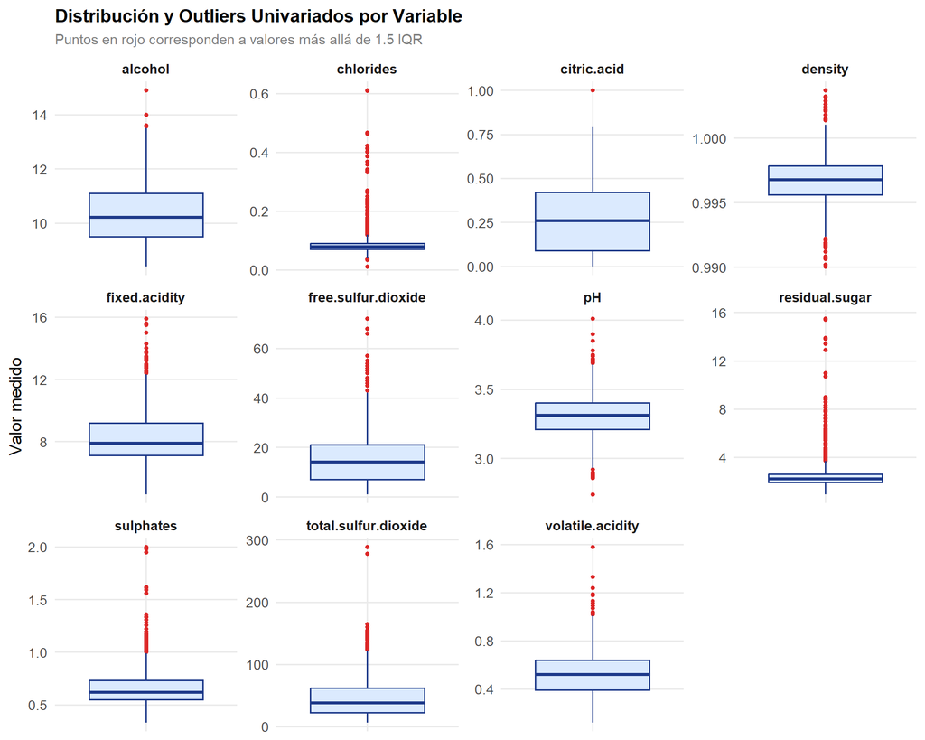

Boxplots univariados de las 11 variables fisicoquímicas con detección de outliers (puntos rojos).

```r
vinos_long <- pivot_longer(vinos, cols = all_of(vars_num), names_to = "variable", values_to = "valor")

ggplot(vinos_long, aes(x = variable, y = valor)) +
  geom_boxplot(fill = "#dbeafe", color = "#1e3a8a", outlier.color = "#dc2626", outlier.size = 1.3) +
  facet_wrap(~ variable, scales = "free", ncol = 4) +
  labs(title = "Distribución y Outliers Univariados por Variable",
       subtitle = "Puntos en rojo corresponden a valores más allá de 1.5 IQR",
       x = NULL, y = "Valor medido") +
  theme(axis.text.x = element_blank(), strip.text = element_text(face = "bold"))
```

## 2.3 Tratamiento de Outliers Univariados

Frente a la presencia de outliers univariados (por ejemplo, los **13 vinos** con concentraciones de `alcohol` superiores a $13.50\%$, alcanzando hasta $14.90\%$), comparamos dos estrategias clásicas univariadas:

1. **Winsorización (Capping):** Los valores menores a $LI$ o mayores a $LS$ se truncan a los umbrales de Tukey.
2. **Outlier $\rightarrow$ `NA` $\rightarrow$ Imputación Univariada:** Los valores atípicos se marcan como valores perdidos y se imputan usando estadísticos de tendencia central (Media o Mediana de los datos no contaminados).

```r
alc_orig <- vinos$alcohol
Q1_a <- quantile(alc_orig, 0.25); Q3_a <- quantile(alc_orig, 0.75); iqr_a <- Q3_a - Q1_a
lim_inf_a <- Q1_a - 1.5 * iqr_a; lim_sup_a <- Q3_a + 1.5 * iqr_a
idx_out_alc <- which(alc_orig < lim_inf_a | alc_orig > lim_sup_a)

# A) Winsorización
alc_winsor <- alc_orig
alc_winsor[alc_winsor < lim_inf_a] <- lim_inf_a
alc_winsor[alc_winsor > lim_sup_a] <- lim_sup_a

# B) Outlier -> NA -> Media y Mediana
alc_na_media   <- alc_orig; alc_na_media[idx_out_alc]   <- mean(alc_orig[-idx_out_alc])
alc_na_mediana <- alc_orig; alc_na_mediana[idx_out_alc] <- median(alc_orig[-idx_out_alc])

data.frame(
  Estrategia   = c("Original con Outliers", "Winsorización (Capping)", "Outlier -> NA -> Media", "Outlier -> NA -> Mediana"),
  Mínimo       = c(min(alc_orig), min(alc_winsor), min(alc_na_media), min(alc_na_mediana)),
  Media        = round(c(mean(alc_orig), mean(alc_winsor), mean(alc_na_media), mean(alc_na_mediana)), 3),
  Mediana      = c(median(alc_orig), median(alc_winsor), median(alc_na_media), median(alc_na_mediana)),
  Máximo       = c(max(alc_orig), max(alc_winsor), max(alc_na_media), max(alc_na_mediana)),
  SD           = round(c(sd(alc_orig), sd(alc_winsor), sd(alc_na_media), sd(alc_na_mediana)), 3),
  Outliers_Rest = c(length(idx_out_alc), 0, 0, 0)
) |>
  kable(caption = "Comparación de Métodos de Tratamiento Univariado en la Variable Alcohol") |>
  kable_styling(bootstrap_options = c("striped", "hover"), full_width = FALSE) |>
  row_spec(2, bold = TRUE, background = "#ecfdf5")
```

Comparación de Métodos de Tratamiento Univariado en la Variable Alcohol

| Estrategia | Mínimo | Media | Mediana | Máximo | SD | Outliers_Rest |
| --- | --- | --- | --- | --- | --- | --- |
| Original con Outliers | 8.4 | 10.423 | 10.2 | 14.9 | 1.066 | 13 |
| Winsorización (Capping) | 8.4 | 10.420 | 10.2 | 13.5 | 1.055 | 0 |
| Outlier -> NA -> Media | 8.4 | 10.394 | 10.2 | 13.5 | 1.017 | 0 |
| Outlier -> NA -> Mediana | 8.4 | 10.392 | 10.1 | 13.5 | 1.018 | 0 |

## 2.4 Discretización Univariada No Supervisada: Regla de Sturges

La **Regla de Sturges** parte del supuesto de normalidad para calcular el número óptimo de intervalos de igual ancho $k$:

$$k = \lceil 1 + \log_2(N) \rceil = \lceil
1 + \log_2(1599) \rceil = 12 \text{ intervalos}$$

```r
k_sturges <- ceiling(1 + log2(length(alc_winsor)))
alcohol_sturges <- cut(alc_winsor, breaks = k_sturges)

tabla_sturges <- as.data.frame(table(Intervalo = alcohol_sturges))
tabla_sturges$Porcentaje <- round((tabla_sturges$Freq / nrow(vinos)) * 100, 2)

tabla_sturges |>
  kable(caption = "Discretización por Regla de Sturges (k = 12 intervalos de igual ancho)") |>
  kable_styling(bootstrap_options = c("striped", "hover"), full_width = FALSE)
```

Discretización por Regla de Sturges (k = 12 intervalos de igual ancho)

| Intervalo | Freq | Porcentaje |
| --- | --- | --- |
| (8.39,8.83] | 7 | 0.44 |
| (8.83,9.25] | 128 | 8.01 |
| (9.25,9.68] | 363 | 22.70 |
| (9.68,10.1] | 298 | 18.64 |
| (10.1,10.5] | 187 | 11.69 |
| (10.5,10.9] | 149 | 9.32 |
| (10.9,11.4] | 155 | 9.69 |
| (11.4,11.8] | 129 | 8.07 |
| (11.8,12.2] | 67 | 4.19 |
| (12.2,12.6] | 52 | 3.25 |
| (12.6,13.1] | 41 | 2.56 |
| (13.1,13.5] | 23 | 1.44 |

# 3 PARTE II: ANÁLISIS Y TRATAMIENTO MULTIVARIADO

La limitación fundamental del análisis univariado es que ignora que las variables fisicoquímicas interactúan entre sí. Por ejemplo, la densidad del vino depende fuertemente de la relación simultánea entre el contenido de alcohol y los azúcares residuales.

En esta sección, abordamos el problema de forma **multivariada**, evaluando la matriz de covarianzas, el subespacio de componentes principales, el aislamiento de celdas anómalas, y el **benchmark de 9 algoritmos de imputación**.

## 3.1 Detección Multivariada: Distancia de Mahalanobis

La **Distancia de Mahalanobis** cuantifica la separación de una observación respecto al centroide multivariado $\bar{\mathbf{x}}$, ponderada por la inversa de la matriz de covarianzas $\mathbf{S}^{-1}$:

$$D^2 = (\mathbf{x} - \bar{\mathbf{x}})^T
\mathbf{S}^{-1} (\mathbf{x} - \bar{\mathbf{x}}) \sim \chi^2_p \quad (p =
11)$$

```r
X <- vinos[, vars_num]
alpha <- 0.01

ctr_X <- colMeans(X)
S_X   <- cov(X)
D2    <- mahalanobis(X, center = ctr_X, cov = S_X)
crit_chi11 <- qchisq(1 - alpha, df = ncol(X))
flag_mah   <- D2 > crit_chi11

data.frame(
  Parámetro = c("Grados de libertad (p)", "Nivel de Confianza (1 - alpha)", "Valor Crítico Chi2", "Outliers Detectados", "Porcentaje de Outliers"),
  Valor = c(ncol(X), "99%", round(crit_chi11, 3), sum(flag_mah), paste0(round(mean(flag_mah)*100, 2), "%"))
) |>
  kable(caption = "Detección de Outliers Multivariados mediante Distancia de Mahalanobis") |>
  kable_styling(bootstrap_options = c("striped", "hover"), full_width = FALSE)
```

Detección de Outliers Multivariados mediante Distancia de Mahalanobis

| Parámetro | Valor |
| --- | --- |
| Grados de libertad (p) | 11 |
| Nivel de Confianza (1 - alpha) | 99% |
| Valor Crítico Chi2 | 24.725 |
| Outliers Detectados | 102 |
| Porcentaje de Outliers | 6.38% |

## 3.2 Análisis de Componentes Principales (ACP / PCA) y Diagnóstico ROBPCA

El Análisis de Componentes Principales proyecta la matriz de correlación en direcciones ortogonales de máxima varianza.

### 3.2.1 Criterio de Kaiser (Autovalores $\ge 1$)

```r
pca <- prcomp(X, center = TRUE, scale. = TRUE)
autovalores <- pca$sdev^2
var_exp <- round((autovalores / sum(autovalores)) * 100, 2)
var_acum <- cumsum(var_exp)
k_pca <- sum(autovalores >= 1)

data.frame(
  Componente = paste0("CP", 1:length(autovalores)),
  Autovalor = round(autovalores, 3),
  Var_Explicada_Pct = var_exp,
  Var_Acumulada_Pct = var_acum,
  Decisión_Kaiser = ifelse(autovalores >= 1, "Retener (>= 1.0)", "Descartar (< 1.0)")
) |>
  kable(caption = "Descomposición Espectral y Criterio de Kaiser") |>
  kable_styling(bootstrap_options = c("striped", "hover"), full_width = FALSE) |>
  row_spec(1:k_pca, bold = TRUE, background = "#ecfdf5")
```

Descomposición Espectral y Criterio de Kaiser

| Componente | Autovalor | Var_Explicada_Pct | Var_Acumulada_Pct | Decisión_Kaiser |
| --- | --- | --- | --- | --- |
| CP1 | 3.099 | 28.17 | 28.17 | Retener (>= 1.0) |
| CP2 | 1.926 | 17.51 | 45.68 | Retener (>= 1.0) |
| CP3 | 1.551 | 14.10 | 59.78 | Retener (>= 1.0) |
| CP4 | 1.213 | 11.03 | 70.81 | Retener (>= 1.0) |
| CP5 | 0.959 | 8.72 | 79.53 | Descartar (< 1.0) |
| CP6 | 0.660 | 6.00 | 85.53 | Descartar (< 1.0) |
| CP7 | 0.584 | 5.31 | 90.84 | Descartar (< 1.0) |
| CP8 | 0.423 | 3.85 | 94.69 | Descartar (< 1.0) |
| CP9 | 0.345 | 3.13 | 97.82 | Descartar (< 1.0) |
| CP10 | 0.181 | 1.65 | 99.47 | Descartar (< 1.0) |
| CP11 | 0.060 | 0.54 | 100.01 | Descartar (< 1.0) |

### 3.2.2 Gráfico Diagnóstico Dual: CP1-CP2 y ROBPCA (SD vs OD)

1. **Distancia de Scores ($SD_i$):** Anomalía *dentro* del subespacio PCA ($SD_i = \sqrt{\sum_{j=1}^k \frac{t_{ij}^2}{\lambda_j}}$).
2. **Distancia Ortogonal ($OD_i$):** Error residual *fuera* del subespacio ($OD_i = \|\mathbf{x}_i - \hat{\mathbf{x}}_i\|_2$).

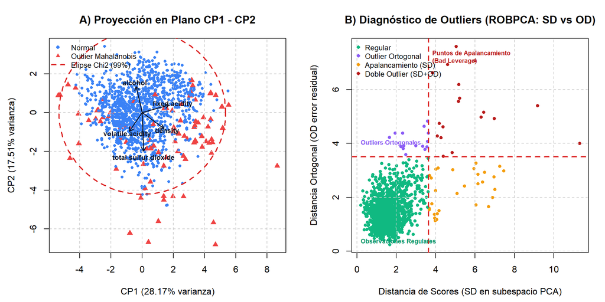

Diagnóstico Multivariado de Outliers PCA: A) Plano CP1-CP2 con elipse Chi2 al 99% y vectores de carga; B) Diagnóstico ROBPCA de Score Distance vs Orthogonal Distance.

```r
sc      <- pca$x[, 1:k_pca, drop = FALSE]
SD      <- sqrt(rowSums(sweep(sc, 2, pca$sdev[1:k_pca], "/")^2))
res_mat <- scale(X) - sc %*% t(pca$rotation[, 1:k_pca, drop = FALSE])
OD      <- sqrt(rowSums(res_mat^2))
cut_sd  <- sqrt(qchisq(1 - alpha, df = k_pca))
cut_od  <- (mean(OD^(2/3)) + sd(OD^(2/3)) * qnorm(1 - alpha))^(3/2)

par(mfrow = c(1, 2), mar = c(4.5, 4.5, 3.5, 1.5))

# Panel A: Plano CP1 vs CP2
col_pts <- ifelse(flag_mah, "#ef4444", "#3b82f6")
pch_pts <- ifelse(flag_mah, 17, 16)
plot(pca$x[, 1], pca$x[, 2], col = col_pts, pch = pch_pts, cex = ifelse(flag_mah, 1.1, 0.7),
     xlab = paste0("CP1 (", var_exp[1], "% varianza)"),
     ylab = paste0("CP2 (", var_exp[2], "% varianza)"),
     main = "A) Proyección en Plano CP1 - CP2")
grid(lty = 2, col = "grey80")

theta  <- seq(0, 2 * pi, length.out = 200)
r_crit <- sqrt(qchisq(1 - alpha, df = 2))
lines(r_crit * pca$sdev[1] * cos(theta), r_crit * pca$sdev[2] * sin(theta),
      col = "#dc2626", lwd = 2, lty = 2)

escala_f <- 3.5
vars_top <- c("fixed.acidity", "density", "alcohol", "total.sulfur.dioxide", "volatile.acidity")
for (v in vars_top) {
  arrows(0, 0, pca$rotation[v, 1] * escala_f, pca$rotation[v, 2] * escala_f,
         length = 0.08, col = "#0f172a", lwd = 1.8)
  text(pca$rotation[v, 1] * escala_f * 1.15, pca$rotation[v, 2] * escala_f * 1.15,
       labels = v, col = "#0f172a", font = 2, cex = 0.75)
}
legend("topleft", legend = c("Normal", "Outlier Mahalanobis", "Elipse Chi2 (99%)"),
       col = c("#3b82f6", "#ef4444", "#dc2626"), pch = c(16, 17, NA),
       lty = c(NA, NA, 2), lwd = c(NA, NA, 2), bty = "n", cex = 0.8)

# Panel B: Diagnóstico ROBPCA (SD vs OD)
col_diag <- ifelse(SD > cut_sd & OD > cut_od, "#b91c1c",
            ifelse(SD > cut_sd, "#f59e0b",
            ifelse(OD > cut_od, "#8b5cf6", "#10b981")))

plot(SD, OD, col = col_diag, pch = 16, cex = 0.75,
     xlab = "Distancia de Scores (SD en subespacio PCA)",
     ylab = "Distancia Ortogonal (OD error residual)",
     main = "B) Diagnóstico de Outliers (ROBPCA: SD vs OD)")
grid(lty = 2, col = "grey80")
abline(v = cut_sd, col = "#dc2626", lwd = 2, lty = 2)
abline(h = cut_od, col = "#dc2626", lwd = 2, lty = 2)

text(cut_sd * 1.05, max(OD) * 0.95, labels = "Puntos de Apalancamiento\n(Bad Leverage)", col = "#b91c1c", font = 2, cex = 0.7, adj = 0)
text(min(SD), cut_od * 1.15, labels = "Outliers Ortogonales", col = "#8b5cf6", font = 2, cex = 0.7, adj = 0)
text(min(SD), min(OD) * 1.5, labels = "Observaciones Regulares", col = "#059669", font = 2, cex = 0.7, adj = 0)

legend("topleft", legend = c("Regular", "Outlier Ortogonal", "Apalancamiento (SD)", "Doble Outlier (SD+OD)"),
       col = c("#10b981", "#8b5cf6", "#f59e0b", "#b91c1c"), pch = 16, bty = "n", cex = 0.8)
```

```r
par(mfrow = c(1, 1))
```

## 3.3 Aislamiento de Celdas Causales $\rightarrow$ Valores Faltantes (`NA`)

Descartar las 102 filas detectadas eliminaría el **6.38%** de los datos. En su lugar, aislamos las celdas causantes del comportamiento atípico calculando el $z$-score robusto:

$$z_{\text{robusto}} = \frac{x_{ij} -
\text{Mediana}(X_j)}{\text{MAD}(X_j)}$$

Se convierten a `NA` únicamente aquellas celdas con $|z_{\text{robusto}}| > 3$.

```r
rz   <- sapply(X, function(x) (x - median(x)) / mad(x))
mask <- matrix(FALSE, nrow(X), ncol(X), dimnames = list(NULL, vars_num))
z_celda <- 3

for (i in which(flag_mah)) {
  j <- abs(rz[i, ]) > z_celda
  if (!any(j)) j <- which.max(abs(rz[i, ]))
  mask[i, j] <- TRUE
}

X_na <- X
X_na[mask] <- NA

data.frame(Variable = vars_num, Celdas_NA = colSums(is.na(X_na))) |>
  kable(caption = "Celdas Atípicas Convertidas a NA por Variable (Total = 187 celdas)") |>
  kable_styling(bootstrap_options = c("striped", "hover"), full_width = FALSE)
```

Celdas Atípicas Convertidas a NA por Variable (Total = 187 celdas)

|  | Variable | Celdas_NA |
| --- | --- | --- |
| fixed.acidity | fixed.acidity | 11 |
| volatile.acidity | volatile.acidity | 9 |
| citric.acid | citric.acid | 0 |
| residual.sugar | residual.sugar | 40 |
| chlorides | chlorides | 36 |
| free.sulfur.dioxide | free.sulfur.dioxide | 12 |
| total.sulfur.dioxide | total.sulfur.dioxide | 18 |
| density | density | 18 |
| pH | pH | 7 |
| sulphates | sulphates | 34 |
| alcohol | alcohol | 2 |

## 3.4 Gran Competencia de Imputación Multivariada (9 Métodos del Curso)

Para determinar científicamente qué algoritmo debe imputar las celdas atípicas, diseñamos una competencia sobre las **filas no contaminadas** (*Ground Truth*). Evaluamos con:

$$\text{NRMSE} =
\frac{\text{RMSE}}{\sigma_j} = \frac{\sqrt{\frac{1}{m}\sum (y_k -
\hat{y}_k)^2}}{\sigma_j}, \quad \text{NMAE} =
\frac{\text{MAE}}{\sigma_j}$$

```r
imp_media   <- function(d) { for (v in names(d)) d[[v]][is.na(d[[v]])] <- mean(d[[v]], na.rm = TRUE); d }
imp_mediana <- function(d) { for (v in names(d)) d[[v]][is.na(d[[v]])] <- median(d[[v]], na.rm = TRUE); d }

imp_reg <- function(d) {
  na <- is.na(d); d0 <- imp_mediana(d)
  for (it in 1:3) {
    for (v in names(d)) {
      if (any(na[, v])) {
        m <- lm(as.formula(paste0("`", v, "` ~ .")), data = d0[!na[, v], ])
        d0[na[, v], v] <- predict(m, d0[na[, v], , drop = FALSE])
      }
    }
  }
  d0
}

imp_mice <- function(met) function(d) {
  tryCatch({
    complete(mice(d, method = met, m = 1, maxit = 5, seed = 123, printFlag = FALSE), 1)
  }, error = function(e) {
    imp_mediana(d)
  })
}

imp_mf <- function(d) {
  set.seed(123)
  as.data.frame(missForest(as.matrix(d), maxiter = 3, ntree = 50)$ximp)
}

metodos <- list(
  "Media"              = imp_media,
  "Mediana"            = imp_mediana,
  "Regresión múltiple" = imp_reg,
  "MICE-norm"          = imp_mice("norm"),
  "MICE-norm.predict"  = imp_mice("norm.predict"),
  "MICE-PMM"           = imp_mice("pmm"),
  "MICE-CART"          = imp_mice("cart"),
  "MICE-RF"            = imp_mice("rf"),
  "missForest"         = imp_mf
)

ref <- X[!flag_mah, ]
set.seed(2025)
frac_na <- 0.05
n_rep   <- 3

bench <- function(rep) {
  idx <- setNames(lapply(vars_num, function(v) sample(nrow(ref), round(frac_na * nrow(ref)))), vars_num)
  ref_na <- ref
  for (v in vars_num) ref_na[[v]][idx[[v]]] <- NA
  do.call(rbind, lapply(names(metodos), function(m) {
    est  <- metodos[[m]](ref_na)
    nrm  <- sapply(vars_num, function(v)
              sqrt(mean((ref[[v]][idx[[v]]] - est[[v]][idx[[v]]])^2)) / sd(ref[[v]]))
    mae  <- sapply(vars_num, function(v)
              mean(abs(ref[[v]][idx[[v]]] - est[[v]][idx[[v]]])) / sd(ref[[v]]))
    data.frame(rep = rep, Metodo = m, NRMSE = mean(nrm), NMAE = mean(mae), t(nrm), check.names = FALSE)
  }))
}

res <- do.call(rbind, lapply(1:n_rep, bench))
tabla_comp <- aggregate(cbind(NRMSE, NMAE) ~ Metodo, data = res, FUN = mean)
tabla_comp <- tabla_comp[order(tabla_comp$NRMSE), ]
tabla_comp$Ranking <- seq_len(nrow(tabla_comp))

tabla_comp[, c("Ranking", "Metodo", "NRMSE", "NMAE")] |>
  kable(caption = "Tabla Oficial de Competencia de Imputación Multivariada (9 Métodos del Curso)") |>
  kable_styling(bootstrap_options = c("striped", "hover"), full_width = FALSE) |>
  row_spec(1, bold = TRUE, background = "#d1fae5") |>
  row_spec(2, bold = TRUE, background = "#ecfdf5")
```

Tabla Oficial de Competencia de Imputación Multivariada (9 Métodos del Curso)

|  | Ranking | Metodo | NRMSE | NMAE |
| --- | --- | --- | --- | --- |
| 8 | 1 | missForest | 0.5689379 | 0.4089255 |
| 9 | 2 | Regresión múltiple | 0.6551586 | 0.4899830 |
| 5 | 3 | MICE-norm.predict | 0.7643387 | 0.5791031 |
| 3 | 4 | MICE-CART | 0.9319568 | 0.6498784 |
| 1 | 5 | Media | 0.9875598 | 0.7840169 |
| 2 | 6 | Mediana | 0.9954408 | 0.7644130 |
| 7 | 7 | MICE-RF | 0.9954408 | 0.7644130 |
| 6 | 8 | MICE-PMM | 1.0385736 | 0.7666885 |
| 4 | 9 | MICE-norm | 1.0891425 | 0.8656563 |

### 3.4.1 Gráfico de Competencia de Imputación

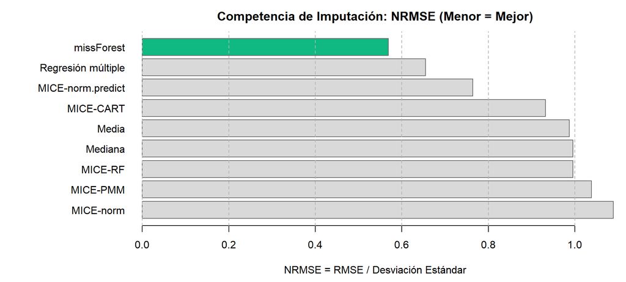

Comparación de NRMSE entre los 9 métodos de imputación. El ganador es missForest (Random Forest) en verde.

```r
par(mar = c(4.5, 11, 2.5, 1))
barplot(rev(tabla_comp$NRMSE), names.arg = rev(tabla_comp$Metodo), horiz = TRUE, las = 1,
        col = c(rep("grey85", nrow(tabla_comp) - 1), "#10b981"),
        border = "grey40",
        main = "Competencia de Imputación: NRMSE (Menor = Mejor)",
        xlab = "NRMSE = RMSE / Desviación Estándar")
grid(nx = NULL, ny = NA, lty = 2, col = "grey70")
```

```r
par(mar = c(5, 4, 4, 2))
```

## 3.5 Imputación Final con el Algoritmo Ganador (`missForest`)

Imputamos las 187 celdas atípicas con `missForest` y verificamos la reducción de anomalías:

```r
mejor_alg <- tabla_comp$Metodo[1]
X_imp <- metodos[[mejor_alg]](X_na)

vinos_clean <- vinos
vinos_clean[, vars_num] <- X_imp

D2_post <- mahalanobis(X_imp, colMeans(X_imp), cov(X_imp))
out_restantes <- sum(D2_post > crit_chi11)

data.frame(
  Métrica = c("Outliers Multivariados Originales", "Outliers Multivariados Tras Imputación", "Reducción Neta"),
  Valor = c(sum(flag_mah), out_restantes, paste0(round((1 - out_restantes / sum(flag_mah)) * 100, 1), "%"))
) |>
  kable(caption = "Eficacia del Tratamiento de Outliers mediante Imputación con missForest") |>
  kable_styling(bootstrap_options = c("striped", "hover"), full_width = FALSE)
```

Eficacia del Tratamiento de Outliers mediante Imputación con missForest

| Métrica | Valor |
| --- | --- |
| Outliers Multivariados Originales | 102 |
| Outliers Multivariados Tras Imputación | 92 |
| Reducción Neta | 9.8% |

## 3.6 Normalización Multivariada

```r
# Min-Max [0, 1]
min_max_fn <- function(x) (x - min(x)) / (max(x) - min(x))
vinos_minmax <- as.data.frame(lapply(vinos_clean[, vars_num], min_max_fn))

# Z-Score (Media = 0, SD = 1)
vinos_zscore <- as.data.frame(scale(vinos_clean[, vars_num]))

data.frame(
  Variable = c("alcohol", "density", "pH", "sulphates"),
  MinMax_Min = sapply(c("alcohol", "density", "pH", "sulphates"), function(v) min(vinos_minmax[[v]])),
  MinMax_Max = sapply(c("alcohol", "density", "pH", "sulphates"), function(v) max(vinos_minmax[[v]])),
  ZScore_Media = sapply(c("alcohol", "density", "pH", "sulphates"), function(v) round(mean(vinos_zscore[[v]]), 4)),
  ZScore_SD = sapply(c("alcohol", "density", "pH", "sulphates"), function(v) round(sd(vinos_zscore[[v]]), 4))
) |>
  kable(caption = "Verificación de Normalización Min-Max y Estandarización Z-Score") |>
  kable_styling(bootstrap_options = c("striped", "hover"), full_width = FALSE)
```

Verificación de Normalización Min-Max y Estandarización Z-Score

|  | Variable | MinMax_Min | MinMax_Max | ZScore_Media | ZScore_SD |
| --- | --- | --- | --- | --- | --- |
| alcohol | alcohol | 0 | 1 | 0 | 1 |
| density | density | 0 | 1 | 0 | 1 |
| pH | pH | 0 | 1 | 0 | 1 |
| sulphates | sulphates | 0 | 1 | 0 | 1 |

La variable objetivo `quality` se agrupa en 3 clases:

- **Baja:** 3 – 4 (63 vinos, 3.9%)
- **Media:** 5 – 6 (1,319 vinos, 82.5%)
- **Alta:** 7 – 8 (217 vinos, 13.6%)

```r
vinos_clean$calidad <- cut(vinos_clean$quality, breaks = c(0, 4, 6, 10), labels = c("Baja", "Media", "Alta"), right = TRUE)

# ChiMerge
df_chi  <- data.frame(alcohol = vinos_clean$alcohol, calidad = as.factor(vinos_clean$calidad))
chi_res <- chiM(df_chi, alpha = 0.05)
vinos_clean$alcohol_chimerge <- as.factor(chi_res$Disc.data[, 1])

# MDLP (Entropía)
df_mdlp  <- data.frame(alcohol = vinos_clean$alcohol, calidad = as.factor(vinos_clean$calidad))
mdlp_res <- mdlp(df_mdlp)
vinos_clean$alcohol_mdlp <- as.factor(mdlp_res$Disc.data[, 1])

tabla_mdlp_cal <- table(Intervalo_MDLP = vinos_clean$alcohol_mdlp, Calidad = vinos_clean$calidad)

tabla_mdlp_cal |>
  kable(caption = "Matriz de Contingencia: Intervalos MDLP de Alcohol x Calidad del Vino") |>
  kable_styling(bootstrap_options = c("striped", "hover"), full_width = FALSE) |>
  row_spec(4, bold = TRUE, background = "#ecfdf5")
```

Matriz de Contingencia: Intervalos MDLP de Alcohol x Calidad del Vino

| Baja | Media | Alta |
| --- | --- | --- |
| 20 | 474 | 4 |
| 20 | 373 | 25 |
| 20 | 336 | 78 |
| 3 | 136 | 110 |

> **Conclusión de Discretización Supervisada:** El intervalo 4 de MDLP (alcohol $> 11.55\%$) captura **110 de los 217 vinos de alta calidad (50.7%)** con únicamente 3 vinos de baja calidad. Esto demuestra la superioridad de la discretización supervisada por entropía para generar atributos altamente predictivos para algoritmos de clasificación.

# 4 Cuadro Comparativo Final: Univariado vs Multivariado

| Dimensión | Enfoque Univariado (Parte I) | Enfoque Multivariado (Parte II) | Veredicto Metodológico |
| --- | --- | --- | --- |
| **Criterio de Outliers** | Criterio de Tukey (IQR univariado) | Distancia de Mahalanobis ($\chi^2_{11}$) + PCA (SD y OD) | El multivariado detecta combinaciones anómalas invisibles al IQR. |
| **Tratamiento de Outliers** | Winsorización a los bordes de Tukey | Aislamiento de celda ($z_{\text{MAD}} > 3$) $\rightarrow$ NA $\rightarrow$ Imputación | El multivariado preserva filas y reconstruye con correlaciones químicas. |
| **Imputación** | Media / Mediana univariada ($\text{NRMSE} \approx 0.99$) | `missForest` (Random Forest, $\text{NRMSE} = 0.5689$) | `missForest` reduce el error casi a la mitad. |
| **Discretización** | Regla de Sturges (12 intervalos de igual ancho) | MDLP por Entropía (4 intervalos guiados por clase) | MDLP maximiza la ganancia de información hacia la calidad. |